# Time Series Analysis of Monthly Drinking Milk Production in Portugal

## 1. Introduction

This study presents a time series analysis of monthly drinking milk production in Portugal, measured in thousand tonnes, covering the period from January 1987 to February 2026. The data were obtained from Eurostat (dataset APRO_MK_COLM) and comprise 470 monthly observations.

Milk production exhibits clear seasonal patterns driven by biological and market cycles, as well as a long-run trend shaped by structural changes in the dairy sector. A particularly notable feature of this series is a sharp and sustained decline beginning around 2015, coinciding with the abolition of EU milk production quotas — a policy change that fundamentally altered production incentives across member states.

The objective of this analysis is to identify and evaluate time series models capable of capturing the seasonality, trend, and structural dynamics present in the data. The methodology proceeds as follows: after exploratory analysis, variance stabilisation, and stationarity testing, a set of SARIMA models is identified and compared. To explicitly account for the 2015 structural break, an ARIMAX extension with a step dummy variable is also considered. Finally, exponential smoothing approaches (ETS and STLM) are fitted as alternatives to the ARIMA family. All models are evaluated on a held-out test set using standard forecast accuracy metrics.

## 2. Data and Exploratory Analysis

### 2.1 Packages

Loading necessary packages

```r
#install.packages(c("readxl","lubridate","dplyr","ggplot2","forecast","tseries","urca","lmtest","MuMIn","kableExtra"))

library(readxl)
library(dplyr)
library(lubridate)
library(ggplot2)
library(forecast)
library(tseries)
library(urca)
library(lmtest)
library(MuMIn)
library(kableExtra)
library(FinTS)
library(knitr)
library(rugarch)
```

### 2.2 Data Loading and Preparation

```r
# Load data
dados <- read.csv("data/leite.csv")
dados
```

| STRUCTURE | STRUCTURE_ID | STRUCTURE_NAME | freq | Time.frequency | milkitem | Item.of.milk | dairyprod | Dairy.and.other.animal.products..except.meat. | unit | Unit.of.measure | geo | Geopolitical.entity..reporting. | TIME_PERIOD | Time | OBS_VALUE | Observation.value | OBS_FLAG | Observation.status..Flag..V2.structure | CONF_STATUS | Confidentiality.status..flag. |
| --- | --- | --- | --- | --- | --- | --- | --- | --- | --- | --- | --- | --- | --- | --- | --- | --- | --- | --- | --- | --- |
| dataflow | ESTAT:APRO_MK_COLM(1.0) | Production of main cows' milk products - monthly data | M | Monthly | PRD | Product obtained | D2100 | Drinking milk | THS_T | Thousand tonnes | PT | Portugal | 1986-01 | NA | 0.00 | NA | n | not significant | NA | NA |
| dataflow | ESTAT:APRO_MK_COLM(1.0) | Production of main cows' milk products - monthly data | M | Monthly | PRD | Product obtained | D2100 | Drinking milk | THS_T | Thousand tonnes | PT | Portugal | 1986-02 | NA | 0.00 | NA | n | not significant | NA | NA |
| dataflow | ESTAT:APRO_MK_COLM(1.0) | Production of main cows' milk products - monthly data | M | Monthly | PRD | Product obtained | D2100 | Drinking milk | THS_T | Thousand tonnes | PT | Portugal | 1986-03 | NA | 0.00 | NA | n | not significant | NA | NA |
| dataflow | ESTAT:APRO_MK_COLM(1.0) | Production of main cows' milk products - monthly data | M | Monthly | PRD | Product obtained | D2100 | Drinking milk | THS_T | Thousand tonnes | PT | Portugal | 1987-01 | NA | 51.70 | NA |  |  | NA | NA |
| dataflow | ESTAT:APRO_MK_COLM(1.0) | Production of main cows' milk products - monthly data | M | Monthly | PRD | Product obtained | D2100 | Drinking milk | THS_T | Thousand tonnes | PT | Portugal | 1987-02 | NA | 51.20 | NA |  |  | NA | NA |
| dataflow | ESTAT:APRO_MK_COLM(1.0) | Production of main cows' milk products - monthly data | M | Monthly | PRD | Product obtained | D2100 | Drinking milk | THS_T | Thousand tonnes | PT | Portugal | 1987-03 | NA | 57.00 | NA |  |  | NA | NA |
| dataflow | ESTAT:APRO_MK_COLM(1.0) | Production of main cows' milk products - monthly data | M | Monthly | PRD | Product obtained | D2100 | Drinking milk | THS_T | Thousand tonnes | PT | Portugal | 1987-04 | NA | 44.80 | NA |  |  | NA | NA |
| dataflow | ESTAT:APRO_MK_COLM(1.0) | Production of main cows' milk products - monthly data | M | Monthly | PRD | Product obtained | D2100 | Drinking milk | THS_T | Thousand tonnes | PT | Portugal | 1987-05 | NA | 58.30 | NA |  |  | NA | NA |
| dataflow | ESTAT:APRO_MK_COLM(1.0) | Production of main cows' milk products - monthly data | M | Monthly | PRD | Product obtained | D2100 | Drinking milk | THS_T | Thousand tonnes | PT | Portugal | 1987-06 | NA | 53.80 | NA |  |  | NA | NA |
| dataflow | ESTAT:APRO_MK_COLM(1.0) | Production of main cows' milk products - monthly data | M | Monthly | PRD | Product obtained | D2100 | Drinking milk | THS_T | Thousand tonnes | PT | Portugal | 1987-07 | NA | 54.50 | NA |  |  | NA | NA |

[output cut: 463 more lines]

```r
dadosSelected <- select(dados, TIME_PERIOD, OBS_VALUE)

dadosSelected <- dadosSelected[-c(1,2, 3), ]

# Ensure numeric values (handles any locale comma decimals)
dadosSelected$OBS_VALUE <- as.numeric(gsub(",", ".", dadosSelected$OBS_VALUE))

head(dadosSelected)
```

|  | TIME_PERIOD | OBS_VALUE |
| --- | --- | --- |
| 4 | 1987-01 | 51.7 |
| 5 | 1987-02 | 51.2 |
| 6 | 1987-03 | 57.0 |
| 7 | 1987-04 | 44.8 |
| 8 | 1987-05 | 58.3 |
| 9 | 1987-06 | 53.8 |

The dataset contains **470 monthly observations** of drinking milk production in Portugal (thousand tonnes), from January 1987 to February 2026, sourced from Eurostat (APRO_MK_COLM).

```r
ts_data <- ts(dadosSelected$OBS_VALUE, start = c(1987, 1), frequency = 12)
```

### 2.3 Outlier Analysis

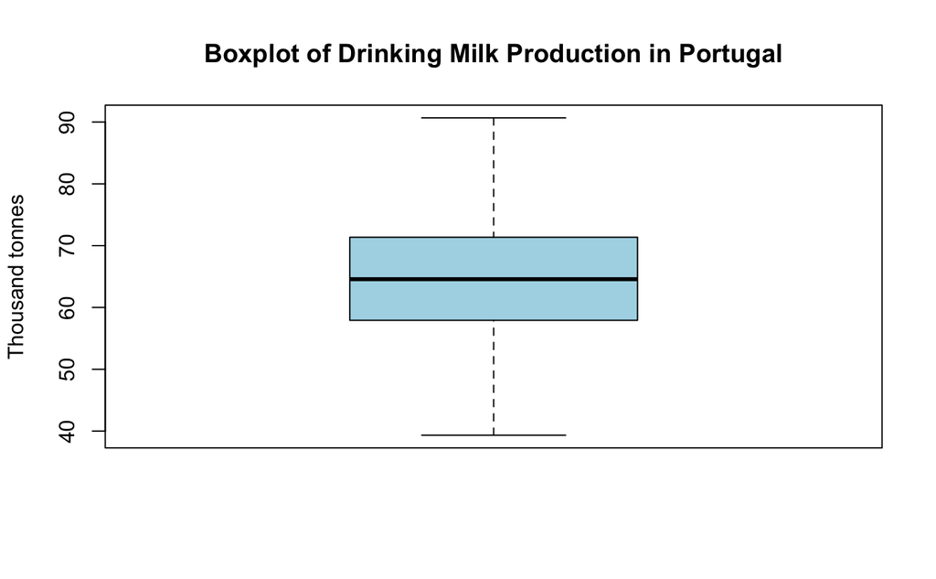

```r
boxplot(dadosSelected$OBS_VALUE, main = "Boxplot of Drinking Milk Production in Portugal", ylab = "Thousand tonnes", col = "lightblue")
```

The boxplot shows no outliers. All observations fall within the expected range.

### 2.4 Time Series Visualisation

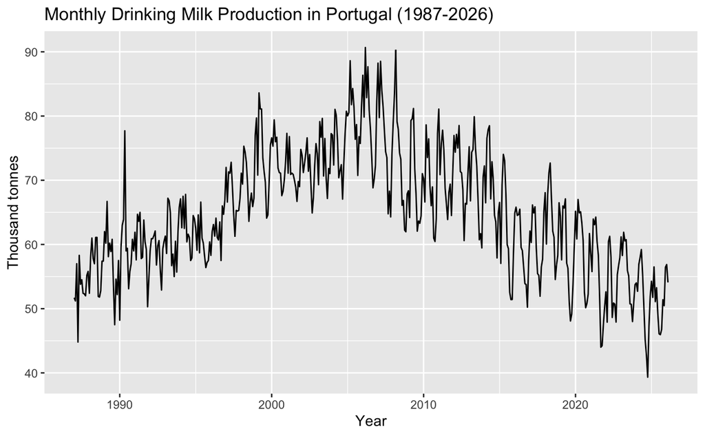

```r
autoplot(ts_data,
         ylab = "Thousand tonnes",
         xlab = "Year",
         main = "Monthly Drinking Milk Production in Portugal (1987-2026)")
```

From the plot we can observe:

1. **Seasonality:** there is a clear repeating pattern every 12 months, visible throughout the whole series.
2. **Trend**: production increases from 1987 until around 2005–2007, reaching a peak of about 90 thousand tonnes, and then steadily decreases to around 40–60 thousand tonnes by 2026.
3. **Variance**: the seasonal swings appear to be larger in the middle of the series (around 2000–2010) than at the beginning and end, which suggests the variance may not be constant. This will be checked formally using a Box–Cox test.
4. **Early period (1987–1991)**: the first five years show atypical irregular oscillations not consistent with the rest of the series, which may reflect data quality issues in the early years of reporting. Notably, a spike of 77.70 thousand tonnes in May 1990 stands out as anomalous for this period. While not flagged as a global outlier by the boxplot, it is clearly inconsistent with the surrounding observations. This will be investigated further during model diagnostics.

### 2.5 Transformation to the Month Length

Months have different lengths (28–31 days), which introduces a spurious seasonal effect. We standardise production to an equivalent month of 30.44 days (365.25/12).

```r
dados_ajustados <- dadosSelected %>%
  mutate(Data_Certa = ym(TIME_PERIOD)) %>% # to make sure is in the right format
  mutate(Dias_no_Mes = days_in_month(Data_Certa)) %>%
  mutate(Adjusted_value = (OBS_VALUE* (365.25/12))/ Dias_no_Mes)
```

```r
ts_adj <- ts(dados_ajustados$Adjusted_value, start = c(1987, 1), frequency = 12)
```

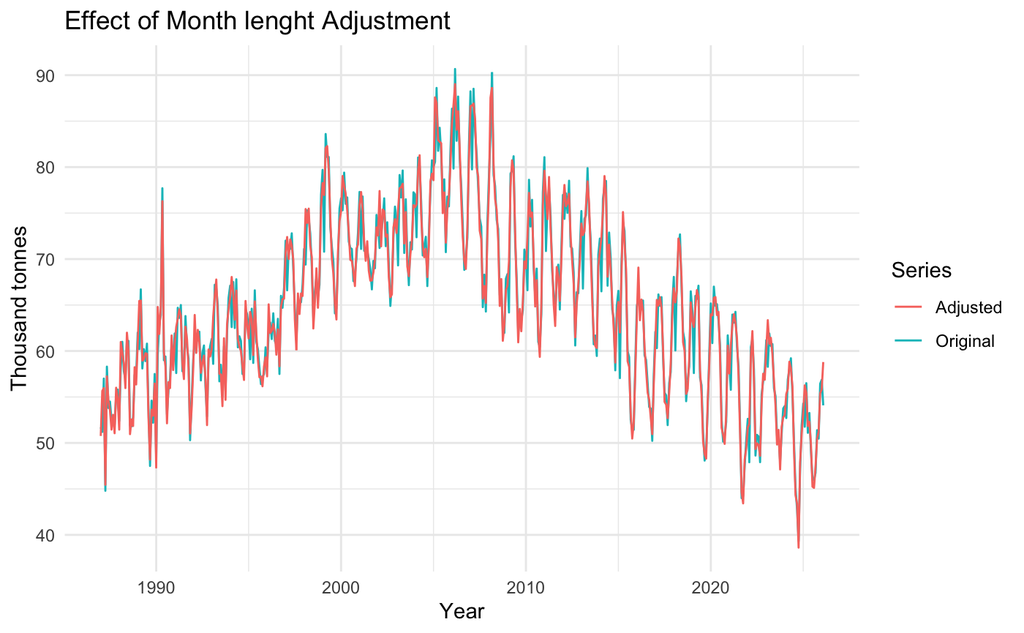

```r
autoplot(ts_data, series = "Original") +
  autolayer(ts_adj , series = "Adjusted") +
  labs(
    x = "Year",
    y = "Thousand tonnes",
    title = "Effect of Month lenght Adjustment"
  ) +
  guides(colour = guide_legend(title = "Series")) +
  theme_minimal()
```

The calendar-adjusted series removes the artefact caused by month length differences. **We will use `ts_adj` for all subsequent analysis.**

### 2.6 Data Split: Training and Test Sets

We split the data into a training set (75%) for model fitting and a test set (25%) for forecast evaluation.

```r
n          <- length(ts_adj)
train_size <- floor(0.75 * n)

ts_train <- window(ts_adj, end   = time(ts_adj)[train_size])
ts_test  <- window(ts_adj, start = time(ts_adj)[train_size + 1])

cat("Training set:", length(ts_train), "observations\n")
```

```
Training set: 352 observations
```

```r
cat("Test set:    ", length(ts_test),  "observations\n")
```

```
Test set:     118 observations
```

All transformations and model fitting are applied **only to the training set** to avoid data leakage.

### 2.7 Decomposition

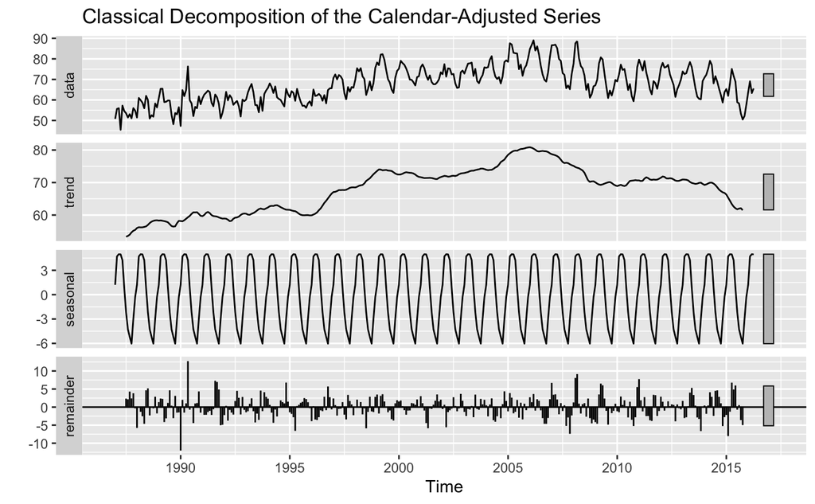

```r
decomposed <- decompose(ts_train)
autoplot(decomposed) +
  labs(title = "Classical Decomposition of the Calendar-Adjusted Series")
```

The decomposition confirms:

- A **trend component** shows a gradual increase from 1987 to a peak around 2005–2007, followed by a period of relative stability, and then a sharp and sustained decline beginning in 2015. This structural break coincides with the abolition of EU milk production quotas and suggests a permanent change in the level and direction of the series, which may pose challenges for standard ARIMA models and will be further investigated in the modelling phase.
- A clear **seasonal component** with period 12, oscillating consistently between approximately −6 and 4.5 throughout the entire series, indicating an additive seasonal pattern.
- A **remainder** that fluctuates around zero with no systematic pattern, suggesting the series is well decomposed. A notable spike is visible around 1989–1990, consistent with the atypical oscillations identified in the early period, reinforcing the need to investigate the impact of this period on model fit.

### 2.8 Variance Stabilisation

We use the Box–Cox procedure to check whether a variance-stabilising transformation is needed. A lambda close to 0 suggests a log transformation; a lambda close to 1 means no transformation is necessary.

```r
lambda <- BoxCox.lambda(ts_train)
cat("Optimal Box-Cox lambda:", round(lambda, 3), "\n")
```

```
Optimal Box-Cox lambda: 0.135
```

```r
if (abs(lambda) < 0.25) {
  cat("Lambda close to 0 -> log transformation recommended.\n")
  ts_train_t <- log(ts_train)
  ts_test_t  <- log(ts_test)
  transformed <- TRUE
} else if (lambda > 0.75 & lambda < 1.25) {
  cat("Lambda close to 1 -> no transformation needed.\n")
  ts_train_t <- ts_train
  ts_test_t  <- ts_test
  transformed <- FALSE
} else {
  cat("Applying Box-Cox transformation with lambda =", round(lambda, 3), "\n")
  ts_train_t <- BoxCox(ts_train, lambda)
  ts_test_t  <- BoxCox(ts_test,  lambda)
  transformed <- TRUE
}
```

```
Lambda close to 0 -> log transformation recommended.
```

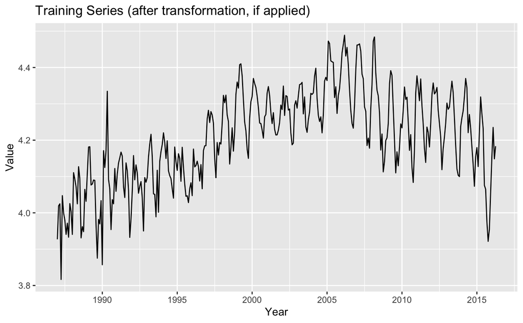

```r
autoplot(ts_train_t,
         main = "Training Series (after transformation, if applied)",
         ylab = "Value", xlab = "Year")
```

### 2.9 Stationarity Assessment

Stationarity can be visually assessed by plotting the ACF/PACF

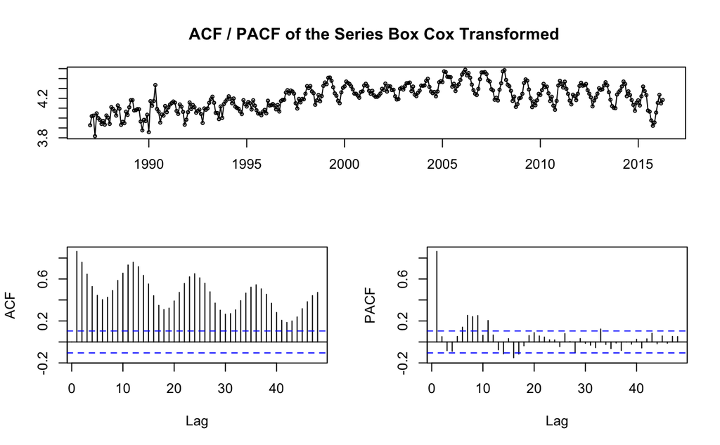

```r
tsdisplay(ts_train_t,
          main = paste0("ACF / PACF of the Series Box Cox Transformed "),
          lag.max = 48)
```

The sample ACF displays a clear periodic structure with significant spikes at lags 12, 24, and 36, alongside a slow decay toward zero, characteristic of a series exhibiting both trend and seasonal non-stationarity. Consequently, the application of one regular difference ($d=1$) and one seasonal difference ($D=1$) is mathematically justified to induce stationarity in the series.

To confirm we use two complementary tests:

- **ADF** (Augmented Dickey–Fuller): H₀ = series has a unit root (non-stationary).
- **KPSS**: H₀ = series is stationary.

```r
adf.test(ts_train_t)
```

```
    Augmented Dickey-Fuller Test

data:  ts_train_t
Dickey-Fuller = -2.1154, Lag order = 7, p-value = 0.5281
alternative hypothesis: stationary
```

```r
kpss.test(ts_train_t)
```

```
    KPSS Test for Level Stationarity

data:  ts_train_t
KPSS Level = 2.9022, Truncation lag parameter = 5, p-value = 0.01
```

```r
cat("Recommended regular differences (ndiffs):  ", ndiffs(ts_train_t),  "\n")
```

```
Recommended regular differences (ndiffs):   1
```

```r
cat("Recommended seasonal differences (nsdiffs):", nsdiffs(ts_train_t), "\n")
```

```
Recommended seasonal differences (nsdiffs): 1
```

Both tests agree that the series is non-stationary:

- **ADF** (p-value = 0.528): fails to reject H₀, indicating the presence of a unit root.
- **KPSS** (p-value < 0.01): rejects H₀, confirming non-stationarity.

The functions `ndiffs()` and `nsdiffs()` recommend **d = 1** regular difference and **D = 1** seasonal difference to achieve stationarity.

### 2.10 Achieving Stationarity through Differencing

We first apply a seasonal difference (lag = 12) to remove the seasonal pattern, then a regular first difference to remove the trend.

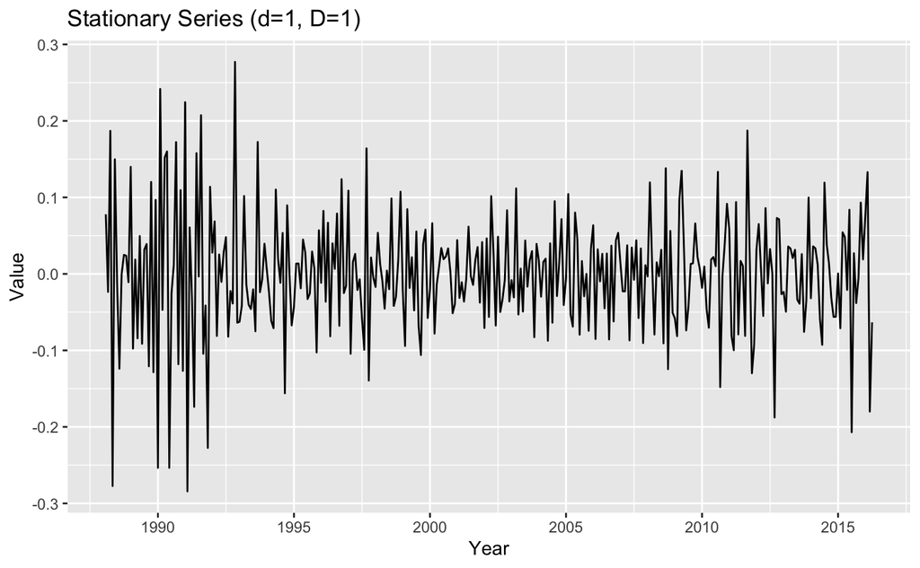

```r
d  <- ndiffs(ts_train_t)
D  <- nsdiffs(ts_train_t)

ts_stationary <- ts_train_t

if (D > 0) {
  ts_stationary <- diff(ts_stationary, lag = 12, differences = D)
}
if (d > 0) {
  ts_stationary <- diff(ts_stationary, differences = d)
}

autoplot(ts_stationary,
         main = paste0("Stationary Series (d=", d, ", D=", D, ")"),
         ylab = "Value", xlab = "Year")
```

We re-run the stationarity tests to confirm.

```r
adf.test(ts_stationary)
```

```
    Augmented Dickey-Fuller Test

data:  ts_stationary
Dickey-Fuller = -10.693, Lag order = 6, p-value = 0.01
alternative hypothesis: stationary
```

```r
kpss.test(ts_stationary)
```

```
    KPSS Test for Level Stationarity

data:  ts_stationary
KPSS Level = 0.019818, Truncation lag parameter = 5, p-value = 0.1
```

After applying one seasonal difference (D=1, lag=12) and one regular difference (d=1), both tests confirm that the series is now stationary:

- **ADF** (p-value < 0.01): rejects H₀, confirming stationarity.
- **KPSS** (p-value > 0.1): fails to reject H₀, confirming stationarity.

The plot shows the series fluctuating around zero with no visible trend or seasonality. Some larger spikes are visible in the early years (1988–1991), consistent with the atypical oscillations identified in Section 2.4, but no systematic pattern remains.

### 2.11 ACF and PACF Analysis

The ACF and PACF of the stationary series are used to identify candidate SARIMA orders.

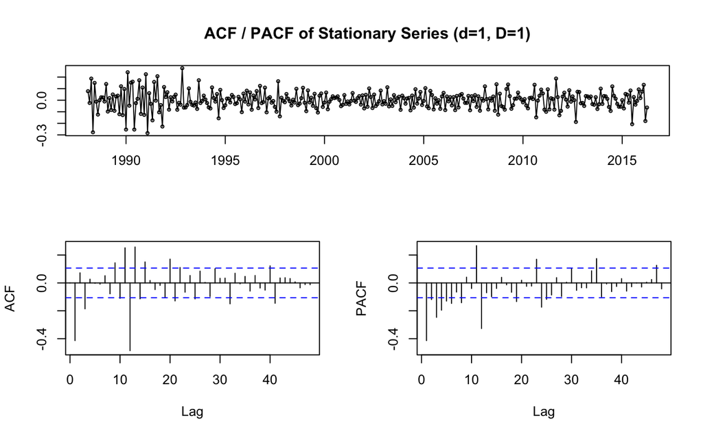

```r
tsdisplay(ts_stationary,
          main = paste0("ACF / PACF of Stationary Series (d=", d, ", D=", D, ")"),
          lag.max = 48)
```

The tentative model is therefore SARIMA(1,1,1)(0,1,1)[12], which will be confirmed by auto.arima() in Section 3.1.

## 3. Model Proposals

All models are fitted on the log-transformed training set (ts_train_t). All forecast evaluation metrics are reported on the log-transformed scale.

### 3.1 Auto ARIMA

We first use `auto.arima()` to search broadly over SARIMA orders and find the best model according to AICc. This serves as a reference to compare against the manually identified model.

```r
auto_fit <- auto.arima(ts_train_t, stepwise = FALSE, approximation = FALSE)
summary(auto_fit)
```

```
Series: ts_train_t
ARIMA(1,1,1)(0,1,1)[12]

Coefficients:
         ar1      ma1     sma1
      0.3183  -0.8381  -0.8304
s.e.  0.0694   0.0387   0.0353

sigma^2 = 0.002745:  log likelihood = 512.75
AIC=-1017.5   AICc=-1017.38   BIC=-1002.2

Training set error measures:
                       ME      RMSE        MAE        MPE      MAPE      MASE        ACF1
Training set -0.004577654 0.0511891 0.03914139 -0.1213605 0.9353549 0.6945115 -0.01398801
```

The selected model is **SARIMA(1,1,1)(0,1,1)[12]**. This is consistent with the ACF/PACF analysis, the presence of spikes at lag 1 in both plots suggested a mixed ARMA(1,1) non-seasonal structure rather than a pure MA(1). All three coefficients are estimated with low standard errors, suggesting they are well-determined by the data. The training MAPE of 0.94% indicates an excellent in-sample fit.

#### Parameter significance and correlation

```r
matriz_vcov <- vcov(auto_fit)
matriz_correlacao <- cov2cor(matriz_vcov)

print(matriz_correlacao)
```

```
             ar1         ma1        sma1
ar1   1.00000000 -0.66569406 -0.04457069
ma1  -0.66569406  1.00000000 -0.04506883
sma1 -0.04457069 -0.04506883  1.00000000
```

The absolute correlation between any two parameters must be less than $0.70$.

The highest correlation observed in the model’s correlation matrix was $-0.67$. Since $|-0.67| = 0.67 < 0.70$, the model satisfies this empirical rule. While close to the threshold, this result indicates no strong evidence of overparameterization or redundancy.

```r
coeftest(auto_fit)
```

```
z test of coefficients:

      Estimate Std. Error  z value  Pr(>|z|)
ar1   0.318343   0.069392   4.5876 4.483e-06 ***
ma1  -0.838100   0.038719 -21.6456 < 2.2e-16 ***
sma1 -0.830387   0.035312 -23.5160 < 2.2e-16 ***
---
Signif. codes:  0 ‘***’ 0.001 ‘**’ 0.01 ‘*’ 0.05 ‘.’ 0.1 ‘ ’ 1
```

All three coefficients are highly significant (p < 0.001), with z-values well above the critical threshold.

#### Residual diagnostics

```
    Ljung-Box test

data:  Residuals from ARIMA(1,1,1)(0,1,1)[12]
Q* = 31.674, df = 21, p-value = 0.06314

Model df: 3.   Total lags used: 24
```

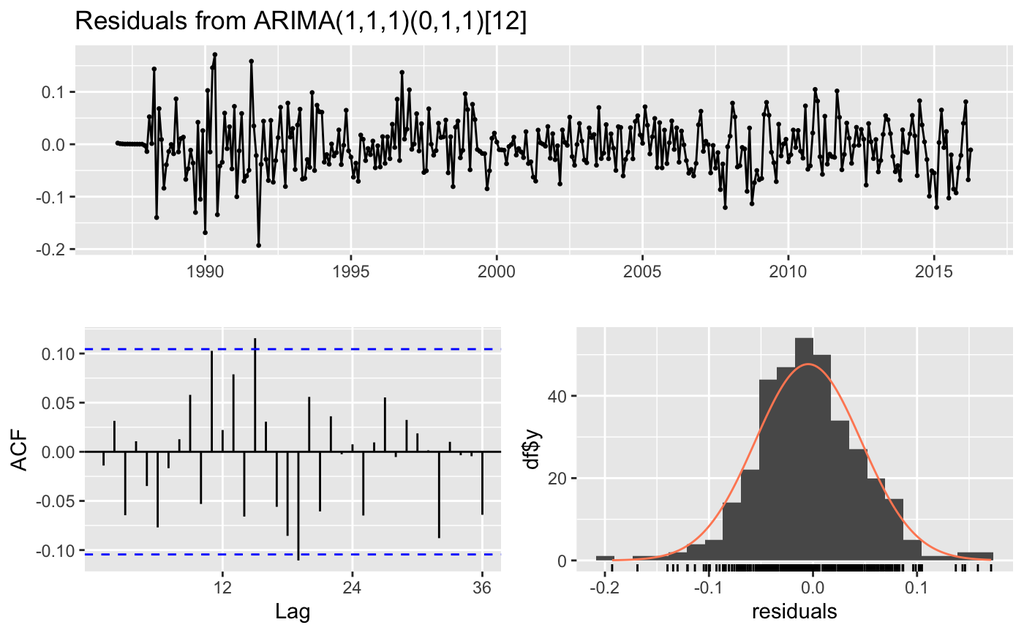

```r
checkresiduals(auto_fit)
```

The residual plot shows values fluctuating around zero with no obvious trend or seasonality. The histogram is approximately bell-shaped, consistent with normality. The **Ljung-Box test** returns a p-value of **0.063**, which is above the 0.05 threshold, meaning we fail to reject the null hypothesis of no autocorrelation (the residuals show no significant serial correlation). However, the residuals exhibit elevated volatility during 1987–1991, consistent with the atypical oscillations identified in the exploratory analysis. This motivates two further investigations: whether the conditional variance of the residuals follows an ARCH process, and whether restricting the series to 1992 onwards improves model adequacy.

#### Residual diagnostics — ARCH test

```r
res_auto <- residuals(auto_fit)

par(mfrow = c(2,2))
plot(res_auto, type = "l", main = "SARIMA residuals")
acf(res_auto,    main = "ACF residuals")
```

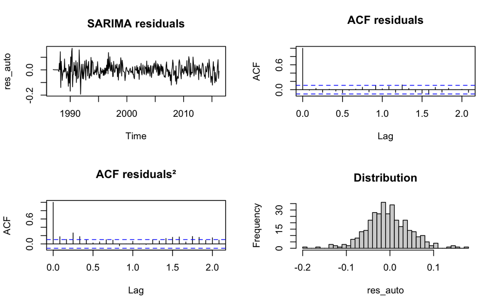

```r
acf(res_auto^2,  main = "ACF residuals²")
hist(res_auto, breaks = 30, main = "Distribution")
```

The residuals fluctuate around zero with no systematic pattern. The ACF of the residuals shows no significant spikes beyond lag 0, consistent with the Ljung-Box result (p = 0.063), indicating that no serial correlation remains. However, the ACF of the squared residuals displays a small number of significant spikes at the early lags, suggesting mild conditional heteroscedasticity.

```r
ArchTest(res_auto, lags = 12)
```

```
    ARCH LM-test; Null hypothesis: no ARCH effects

data:  res_auto
Chi-squared = 41.112, df = 12, p-value = 4.693e-05
```

The ARCH LM test returns Chi-squared = 41.112, df = 12, p-value = 4.693e-05, rejecting H₀ of no ARCH effects. Although less pronounced than typical financial series, significant conditional heteroscedasticity is present in the residuals, justifying the fitting of a GARCH(1,1) model.

#### GARCH(1,1) fit

```r
spec.garch <- ugarchspec(
  variance.model = list(model = "sGARCH", garchOrder = c(1,1)),
  mean.model     = list(armaOrder = c(0,0), include.mean = FALSE)
)
fit.garch <- ugarchfit(spec = spec.garch, data = res_auto)
show(fit.garch)
```

```
*---------------------------------*
*          GARCH Model Fit        *
*---------------------------------*

Conditional Variance Dynamics
-----------------------------------
GARCH Model : sGARCH(1,1)
Mean Model  : ARFIMA(0,0,0)
Distribution    : norm

Optimal Parameters
------------------------------------
        Estimate  Std. Error  t value Pr(>|t|)
omega   0.000282    0.000123   2.2836 0.022397
alpha1  0.167879    0.060847   2.7590 0.005797
beta1   0.732445    0.081988   8.9336 0.000000

Robust Standard Errors:
        Estimate  Std. Error  t value Pr(>|t|)
omega   0.000282    0.000151   1.8736 0.060982
alpha1  0.167879    0.059974   2.7992 0.005123
beta1   0.732445    0.086398   8.4776 0.000000

LogLikelihood : 563.192

Information Criteria
------------------------------------

Akaike       -3.1829
Bayes        -3.1500
Shibata      -3.1831
Hannan-Quinn -3.1698

Weighted Ljung-Box Test on Standardized Residuals
------------------------------------
                        statistic p-value
Lag[1]                    0.07952  0.7779
Lag[2*(p+q)+(p+q)-1][2]   0.99374  0.5003
Lag[4*(p+q)+(p+q)-1][5]   2.09239  0.5968
d.o.f=0
```

[output cut: 33 more lines]

```
Negative Sign Bias  1.5096 0.1320
Positive Sign Bias  0.1477 0.8827
Joint Effect        3.0735 0.3804


Adjusted Pearson Goodness-of-Fit Test:
------------------------------------
  group statistic p-value(g-1)
1    20     20.95      0.33932
2    30     37.83      0.12617
3    40     53.00      0.06668
4    50     61.35      0.11082


Elapsed time : 0.01396704
```

The GARCH(1,1) model assumes the conditional variance follows an ARMA(1,1) structure:
$$\sigma_t^2 = \omega +
\alpha_1 \varepsilon_{t-1}^2 + \beta_1 \sigma_{t-1}^2$$
where $\alpha_1$ captures the impact of past shocks on current variance and $\beta_1$ captures the persistence of past variance. Since the SARIMA residuals have mean $\mu = 0$ by construction, the mean term is excluded from the specification. All three coefficients are statistically significant (p < 0.05). The estimated $\alpha_1 = 0.168$ indicates moderate sensitivity to recent shocks, while $\beta_1 = 0.732$ reflects high persistence in volatility. The sum $\alpha_1 + \beta_1 = 0.900 < 1$ confirms stationarity of the variance process, while its proximity to 1 suggests that volatility shocks dissipate slowly over time.

#### Standardized residuals diagnostics

```r
std.res_auto <- residuals(fit.garch, standardize = TRUE)

par(mfrow = c(2,2))
plot(std.res_auto, type = "l", main = "Standardized residuals")
acf(std.res_auto,    main = "ACF standardized residuals")
```

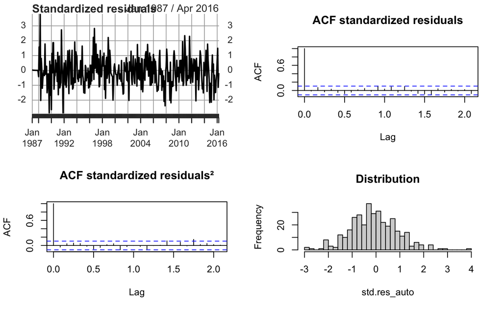

```r
acf(std.res_auto^2,  main = "ACF standardized residuals²")
hist(std.res_auto, breaks = 30, main = "Distribution")
```

The standardized residuals fluctuate around zero with no visible pattern, and the histogram is approximately bell-shaped.

```r
ArchTest(std.res_auto, lags = 12)
```

```
    ARCH LM-test; Null hypothesis: no ARCH effects

data:  std.res_auto
Chi-squared = 13.055, df = 12, p-value = 0.3651
```

The ARCH LM test on the standardized residuals returns p = 0.365 > 0.05 — we fail to reject H₀. The conditional heteroscedasticity has been successfully captured by the GARCH(1,1) model.

#### Forecast Auto Arima

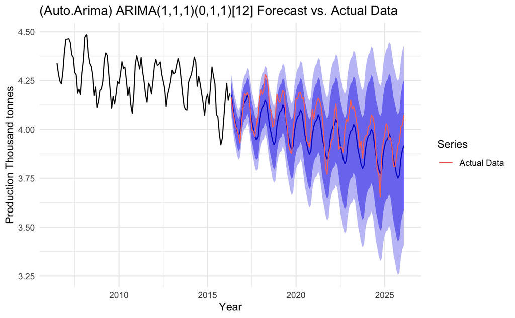

```r
forecast_horizon <- length(ts_test_t)
sarima_forecast <- forecast(auto_fit, h = forecast_horizon)

autoplot(sarima_forecast, include = forecast_horizon) +
  autolayer(ts_test_t, series = "Actual Data") +
  labs(title = "(Auto.Arima) ARIMA(1,1,1)(0,1,1)[12] Forecast vs. Actual Data",
       x = "Year", y = "Production Thousand tonnes") +
  guides(colour = guide_legend(title = "Series")) +
  theme_minimal()
```

```r
accuracy(sarima_forecast, ts_test_t)
```

```
                       ME       RMSE        MAE        MPE      MAPE      MASE        ACF1 Theil's U
Training set -0.004577654 0.05118910 0.03914139 -0.1213605 0.9353549 0.6945115 -0.01398801        NA
Test set      0.054496693 0.08515086 0.07110313  1.3276838 1.7568284 1.2616296  0.68440326  1.273755
```

### 3.2 Sample Period Selection — Restricting to 1992

The residual diagnostics of the full-series model revealed elevated volatility during 1987–1991, consistent with the atypical oscillations identified in the exploratory analysis. To assess whether this early period degrades model quality, we fit the same SARIMA model on the series restricted to January 1992 onwards and compare the results.

```r
ts_adj_92     <- window(ts_adj, start = c(1992, 1))
n_92          <- length(ts_adj_92)
train_size_92 <- floor(0.75 * n_92)

ts_train_92   <- window(ts_adj_92, end   = time(ts_adj_92)[train_size_92])
ts_test_92    <- window(ts_adj_92, start = time(ts_adj_92)[train_size_92 + 1])

ts_train_92_t <- log(ts_train_92)
ts_test_92_t  <- log(ts_test_92)

auto_fit_92 <- auto.arima(ts_train_92_t, stepwise = FALSE, approximation = FALSE)
summary(auto_fit_92)
```

```
Series: ts_train_92_t
ARIMA(1,1,1)(0,1,1)[12]

Coefficients:
         ar1      ma1     sma1
      0.3957  -0.8283  -0.8003
s.e.  0.0760   0.0435   0.0396

sigma^2 = 0.001951:  log likelihood = 495.11
AIC=-982.22   AICc=-982.08   BIC=-967.48

Training set error measures:
                       ME       RMSE        MAE         MPE      MAPE      MASE         ACF1
Training set -0.003345248 0.04300193 0.03378914 -0.08817811 0.7997585 0.6493335 -0.004954321
```

```
    Ljung-Box test

data:  Residuals from ARIMA(1,1,1)(0,1,1)[12]
Q* = 20.983, df = 21, p-value = 0.46

Model df: 3.   Total lags used: 24
```

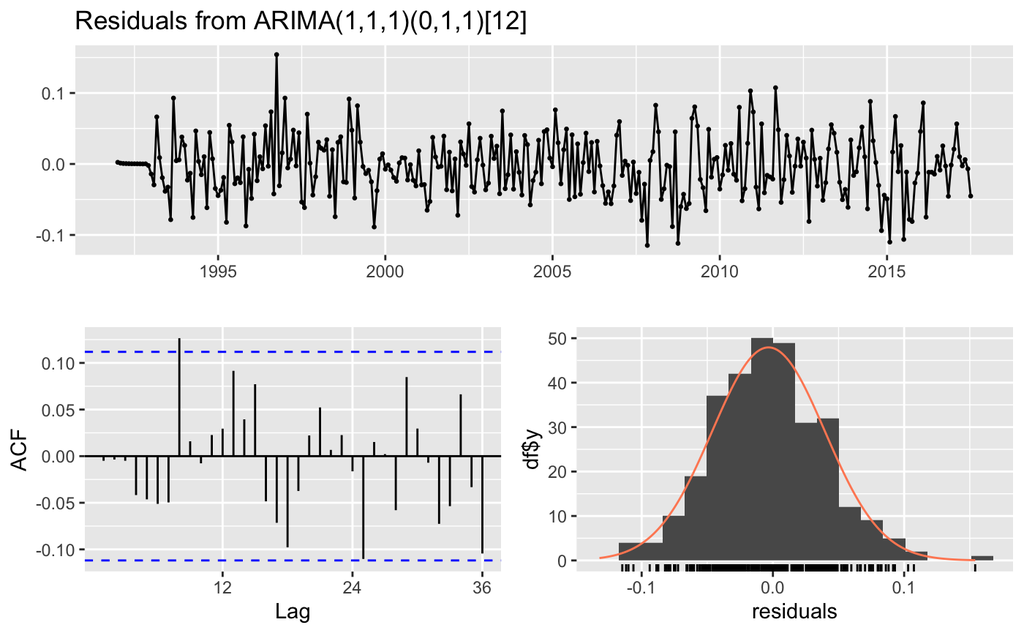

```r
checkresiduals(auto_fit_92)
```

```r
sarima_forecast_92 <- forecast(auto_fit_92, h = length(ts_test_92_t))
accuracy(sarima_forecast_92, ts_test_92_t)
```

```
                       ME       RMSE        MAE         MPE      MAPE      MASE         ACF1 Theil's U
Training set -0.003345248 0.04300193 0.03378914 -0.08817811 0.7997585 0.6493335 -0.004954321        NA
Test set      0.098506429 0.11840581 0.10378928  2.42717660 2.5658169 1.9945418  0.620005939  1.739025
```

The restricted series yields substantially better in-sample diagnostics — the Ljung-Box test improves from p = 0.063 to p = 0.460 and the residual variance reduces from 0.00275 to 0.00195. However, the out-of-sample performance deteriorates, with the test MAPE increasing from 1.76% to 2.57% and Theil’s U from 1.274 to 1.739. Both models struggle in the forecast period due to the 2015 structural break, but the restricted model has less historical data to learn the pre-break dynamics. Given the substantially improved residual diagnostics and the shared limitation of the structural break, the series from 1992 is retained for all subsequent modelling.

```r
lb_full <- Box.test(residuals(auto_fit),    lag = 24, type = "Ljung-Box", fitdf = 3)$p.value
lb_92   <- Box.test(residuals(auto_fit_92), lag = 24, type = "Ljung-Box", fitdf = 3)$p.value

acc_full <- accuracy(sarima_forecast,    ts_test_t)[2,  "MAPE"]
acc_92   <- accuracy(sarima_forecast_92, ts_test_92_t)[2, "MAPE"]

period_comparison <- data.frame(
  Series          = c("Full series (1987–2026)", "Restricted series (1992–2026)"),
  `Ljung-Box p`   = round(c(lb_full, lb_92), 4),
  AIC             = round(c(AIC(auto_fit), AIC(auto_fit_92)), 2),
  `MAPE test (%)`  = round(c(acc_full, acc_92), 3)
)
period_comparison %>%
  kable(row.names = FALSE, caption = "SARIMA(1,1,1)(0,1,1)[12] — Full Series vs. 1992 Onwards") %>%
  kable_styling(bootstrap_options = c("striped", "hover", "condensed"), full_width = FALSE)
```

SARIMA(1,1,1)(0,1,1)[12] — Full Series vs. 1992 Onwards

| Series | Ljung.Box.p | AIC | MAPE.test.... |
| --- | --- | --- | --- |
| Full series (1987–2026) | 0.0631 | -1017.50 | 1.757 |
| Restricted series (1992–2026) | 0.4600 | -982.22 | 2.566 |

**Note:** AIC values are not directly comparable across different sample sizes and are shown for reference only.

```r
ts_adj     <- ts_adj_92
ts_train   <- ts_train_92
ts_test    <- ts_test_92
ts_train_t <- ts_train_92_t
ts_test_t  <- ts_test_92_t
```

### 3.3 Manual SARIMA — SARIMA(1,1,1)(1,1,1)[12]

```r
manual_fit <- Arima(ts_train_t,
                    order    = c(1, 1, 1),
                    seasonal = c(1, 1, 1),
                    method = "ML" # Maximum Likelihood
                    )
summary(manual_fit)
```

```
Series: ts_train_t
ARIMA(1,1,1)(1,1,1)[12]

Coefficients:
         ar1      ma1    sar1     sma1
      0.3928  -0.8305  0.0584  -0.8200
s.e.  0.0761   0.0436  0.0716   0.0441

sigma^2 = 0.001953:  log likelihood = 495.44
AIC=-980.89   AICc=-980.68   BIC=-962.47

Training set error measures:
                       ME       RMSE        MAE         MPE      MAPE      MASE        ACF1
Training set -0.003401265 0.04295371 0.03366578 -0.08947866 0.7969373 0.6469628 -0.00565404
```

```r
cov2cor(vcov(manual_fit))
```

```
             ar1         ma1        sar1        sma1
ar1   1.00000000 -0.69652623 -0.04644690 -0.01915653
ma1  -0.69652623  1.00000000 -0.06632368  0.00346047
sar1 -0.04644690 -0.06632368  1.00000000 -0.53279841
sma1 -0.01915653  0.00346047 -0.53279841  1.00000000
```

The highest correlation in the parameter matrix is between ar1 and ma1 (−0.697), just below the 0.70 threshold. While close, this does not constitute strong evidence of overparameterization.

#### Parameter significance

```r
coeftest(manual_fit)
```

```
z test of coefficients:

      Estimate Std. Error  z value  Pr(>|z|)
ar1   0.392802   0.076101   5.1616 2.448e-07 ***
ma1  -0.830548   0.043555 -19.0688 < 2.2e-16 ***
sar1  0.058357   0.071616   0.8149    0.4151
sma1 -0.819951   0.044082 -18.6004 < 2.2e-16 ***
---
Signif. codes:  0 ‘***’ 0.001 ‘**’ 0.01 ‘*’ 0.05 ‘.’ 0.1 ‘ ’ 1
```

Three of the four parameters are highly significant (p < 0.001). However, the seasonal AR term sar1 is not statistically significant (p = 0.415), with a small estimate of 0.058, suggesting it adds no meaningful information to the model.

#### Residual diagnostics

```
    Ljung-Box test

data:  Residuals from ARIMA(1,1,1)(1,1,1)[12]
Q* = 21.111, df = 20, p-value = 0.3906

Model df: 4.   Total lags used: 24
```

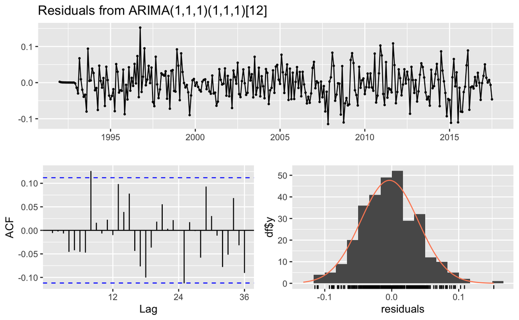

```r
checkresiduals(manual_fit)
```

#### Forecast

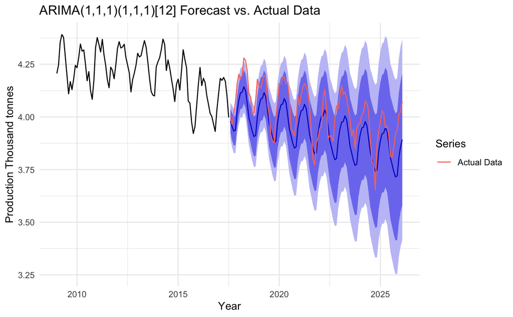

```r
forecast_horizon <- length(ts_test_t)
sarima_manual_forecast <- forecast(manual_fit, h = forecast_horizon)

autoplot(sarima_manual_forecast, include = forecast_horizon) +
  autolayer(ts_test_t, series = "Actual Data") +
  labs(title = "ARIMA(1,1,1)(1,1,1)[12] Forecast vs. Actual Data",
       x = "Year", y = "Production Thousand tonnes") +
  guides(colour = guide_legend(title = "Series")) +
  theme_minimal()
```

```r
accuracy(sarima_manual_forecast, ts_test_t)
```

```
                       ME       RMSE        MAE         MPE      MAPE      MASE        ACF1 Theil's U
Training set -0.003401265 0.04295371 0.03366578 -0.08947866 0.7969373 0.6469628 -0.00565404        NA
Test set      0.087083532 0.10863106 0.09463264  2.14024599 2.3380024 1.8185766  0.62147667  1.593336
```

### 3.4 Structural Break Diagnostic — Pre-2015 Model

Although the SARIMA(1,1,1)(0,1,1)[12] fitted on the series from 1992 passes the Ljung-Box test (p = 0.460), the poor out-of-sample performance (Theil’s U > 1) suggests the 2015 structural break continues to challenge the model’s predictive ability. To confirm this, we fit the same model on training data restricted to before 2015. If diagnostics improve further, it confirms that the structural break, not the model specification, is the primary remaining limitation.

```r
ts_train_pre2015 <- window(ts_train_t, end = c(2014, 12))

fit_pre2015 <- Arima(ts_train_pre2015,
                     order    = c(1, 1, 1),
                     seasonal = c(0, 1, 1))
summary(fit_pre2015)
```

```
Series: ts_train_pre2015
ARIMA(1,1,1)(0,1,1)[12]

Coefficients:
         ar1      ma1     sma1
      0.3726  -0.8329  -0.8029
s.e.  0.0806   0.0461   0.0463

sigma^2 = 0.001913:  log likelihood = 444.86
AIC=-881.73   AICc=-881.57   BIC=-867.44

Training set error measures:
                       ME       RMSE        MAE        MPE      MAPE      MASE         ACF1
Training set -0.002630099 0.04245039 0.03356115 -0.0700103 0.7916732 0.6853934 -0.003307669
```

The pre-2015 training set covers the period from January 1992 to December 2014. The training MAPE of 0.79% reflects an excellent in-sample fit.

```r
cov2cor(vcov(fit_pre2015))
```

```
             ar1         ma1        sma1
ar1   1.00000000 -0.69519100 -0.04607682
ma1  -0.69519100  1.00000000 -0.01449768
sma1 -0.04607682 -0.01449768  1.00000000
```

The highest correlation is between `ar1` and `ma1` (−0.695), just below the 0.70 threshold, indicating no evidence of overparameterization.

#### Parameter significance — Pre-2015 model

```r
coeftest(fit_pre2015)
```

```
z test of coefficients:

      Estimate Std. Error  z value  Pr(>|z|)
ar1   0.372645   0.080567   4.6253 3.741e-06 ***
ma1  -0.832874   0.046131 -18.0545 < 2.2e-16 ***
sma1 -0.802866   0.046261 -17.3551 < 2.2e-16 ***
---
Signif. codes:  0 ‘***’ 0.001 ‘**’ 0.01 ‘*’ 0.05 ‘.’ 0.1 ‘ ’ 1
```

All three parameters are highly significant (p < 0.001), confirming a well-determined model on the pre-break period.

#### Residual diagnostics — Pre-2015 model

```
    Ljung-Box test

data:  Residuals from ARIMA(1,1,1)(0,1,1)[12]
Q* = 19.826, df = 21, p-value = 0.5323

Model df: 3.   Total lags used: 24
```

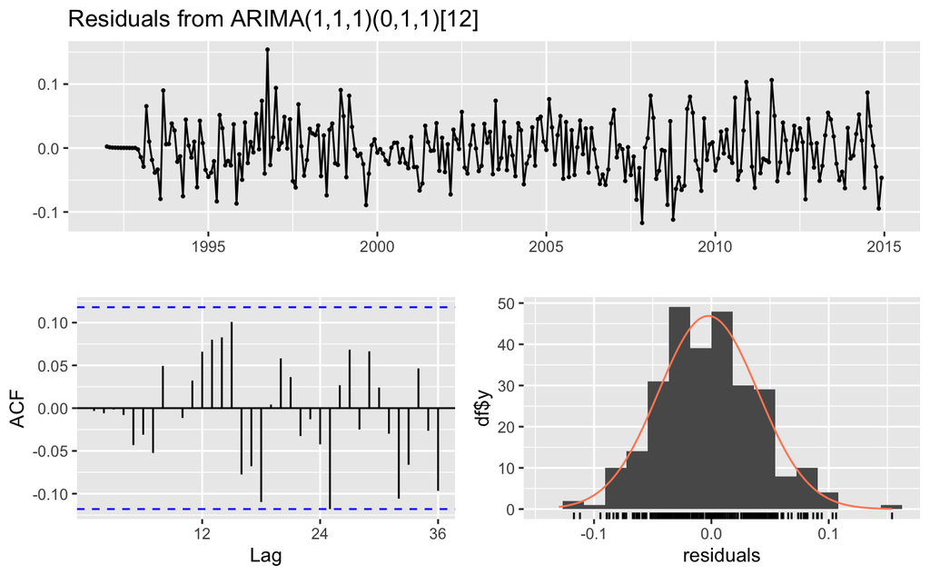

```r
checkresiduals(fit_pre2015)
```

```r
period_diag <- data.frame(
  Model  = rep("SARIMA(1,1,1)(0,1,1)[12]", 3),
  Period = c("Full series (1987–2026)", "From 1992", "Pre-2015 (1992–2014)"),
  `Ljung-Box p`    = c(0.063, 0.460, 0.532),
  `Training MAPE`  = c(0.94,  0.80,  0.79),
  `sigma²`         = c(0.00275, 0.00195, 0.00191),
  check.names = FALSE
)

period_diag %>%
  kable(row.names = FALSE, caption = "SARIMA(1,1,1)(0,1,1)[12] — Diagnostics Across Sample Periods") %>%
  kable_styling(bootstrap_options = c("striped", "hover", "condensed"), full_width = FALSE)
```

SARIMA(1,1,1)(0,1,1)[12] — Diagnostics Across Sample Periods

| Model | Period | Ljung-Box p | Training MAPE | sigma² |
| --- | --- | --- | --- | --- |
| SARIMA(1,1,1)(0,1,1)[12] | Full series (1987–2026) | 0.063 | 0.94 | 0.00275 |
| SARIMA(1,1,1)(0,1,1)[12] | From 1992 | 0.460 | 0.80 | 0.00195 |
| SARIMA(1,1,1)(0,1,1)[12] | Pre-2015 (1992–2014) | 0.532 | 0.79 | 0.00191 |

The pre-2015 model yields the best diagnostics of the three periods, with Ljung-Box p = 0.532 and the lowest residual variance (sigma² = 0.00191). The consistent improvement across the three periods confirms a clear pattern: the 2015 structural break is the primary remaining challenge for the SARIMA model, motivating its explicit modelling via ARIMAX in Section 3.5.

### 3.5 ARIMAX — SARIMA(1,1,1)(0,1,1)[12] with Structural Break Dummy

To model the full series while accounting for the 2015 structural break, we extend SARIMA(1,1,1)(0,1,1)[12] with an exogenous step-change dummy variable (0 before 2015, 1 from January 2015 onwards). This formulation, known as ARIMAX, estimates the permanent level shift caused by the abolition of EU milk quotas as a regression coefficient, allowing the ARIMA errors to remain stationary.

```r
dummy_train <- as.numeric(time(ts_train_t) >= 2015)
dummy_test  <- as.numeric(time(ts_test_t)  >= 2015)

fit_arimax <- Arima(ts_train_t,
                    order    = c(1, 1, 1),
                    seasonal = c(0, 1, 1),
                    xreg     = dummy_train)
summary(fit_arimax)
```

```
Series: ts_train_t
Regression with ARIMA(1,1,1)(0,1,1)[12] errors

Coefficients:
         ar1      ma1     sma1     xreg
      0.3849  -0.8441  -0.7937  -0.0771
s.e.  0.0733   0.0401   0.0401   0.0331

sigma^2 = 0.001926:  log likelihood = 497.64
AIC=-985.27   AICc=-985.06   BIC=-966.85

Training set error measures:
                       ME       RMSE        MAE         MPE      MAPE      MASE         ACF1
Training set -0.002964599 0.04264953 0.03351961 -0.07910214 0.7931504 0.6441538 -0.004784924
```

The ARIMAX model extends SARIMA(1,1,1)(0,1,1)[12] with a step dummy estimating the level shift caused by the 2015 structural break. The training MAPE of 0.79% reflects an excellent in-sample fit.

```r
cov2cor(vcov(fit_arimax))
```

```
             ar1          ma1         sma1        xreg
ar1   1.00000000 -0.662752371 -0.079176896  0.02671063
ma1  -0.66275237  1.000000000 -0.008526736  0.11384114
sma1 -0.07917690 -0.008526736  1.000000000 -0.04149245
xreg  0.02671063  0.113841137 -0.041492452  1.00000000
```

The highest correlation is between `ar1` and `ma1` (−0.663), well below the 0.70 threshold, indicating no evidence of overparameterization.

#### Parameter significance — ARIMAX

```r
coeftest(fit_arimax)
```

```
z test of coefficients:

      Estimate Std. Error  z value  Pr(>|z|)
ar1   0.384870   0.073291   5.2513 1.511e-07 ***
ma1  -0.844078   0.040129 -21.0341 < 2.2e-16 ***
sma1 -0.793685   0.040123 -19.7815 < 2.2e-16 ***
xreg -0.077101   0.033144  -2.3262   0.02001 *
---
Signif. codes:  0 ‘***’ 0.001 ‘**’ 0.01 ‘*’ 0.05 ‘.’ 0.1 ‘ ’ 1
```

All four parameters are statistically significant. The `xreg` coefficient of −0.077 (p = 0.020) confirms a significant negative level shift from January 2015 onwards, consistent with the decline in production following the abolition of EU milk quotas. The ARIMA parameters remain well-determined with low standard errors.

#### Residual diagnostics — ARIMAX

```
    Ljung-Box test

data:  Residuals from Regression with ARIMA(1,1,1)(0,1,1)[12] errors
Q* = 22.727, df = 21, p-value = 0.3587

Model df: 3.   Total lags used: 24
```

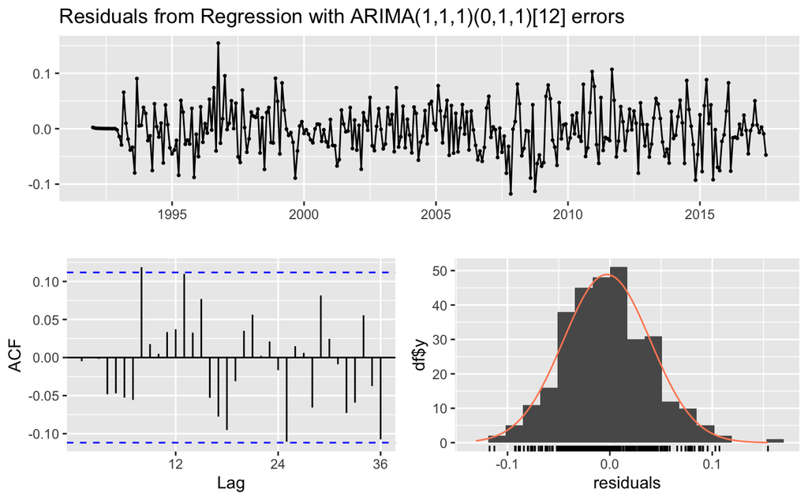

```r
checkresiduals(fit_arimax)
```

The residuals fluctuate around zero with no visible pattern, and the histogram is approximately normal. The Ljung-Box test returns p = 0.359, comfortably failing to reject H₀ — the residuals show no significant autocorrelation.

#### AIC comparison — SARIMA vs ARIMAX

```r
break_comparison <- data.frame(
  Model = c("SARIMA(1,1,1)(0,1,1)[12]", "ARIMAX(1,1,1)(0,1,1)[12] + break dummy"),
  AIC   = round(c(AIC(auto_fit_92), AIC(fit_arimax)), 2),
  AICc  = round(c(AICc(auto_fit_92), AICc(fit_arimax)), 2),
  BIC   = round(c(BIC(auto_fit_92), BIC(fit_arimax)), 2)
)
break_comparison$ΔAIC <- round(break_comparison$AIC - min(break_comparison$AIC), 2)
break_comparison %>%
  kable(row.names = FALSE, caption = "SARIMA vs ARIMAX with Structural Break Dummy") %>%
  kable_styling(bootstrap_options = c("striped", "hover", "condensed"), full_width = FALSE)
```

SARIMA vs ARIMAX with Structural Break Dummy

| Model | AIC | AICc | BIC | ΔAIC |
| --- | --- | --- | --- | --- |
| SARIMA(1,1,1)(0,1,1)[12] | -982.22 | -982.08 | -967.48 | 3.05 |
| ARIMAX(1,1,1)(0,1,1)[12] + break dummy | -985.27 | -985.06 | -966.85 | 0.00 |

#### Forecast — ARIMAX

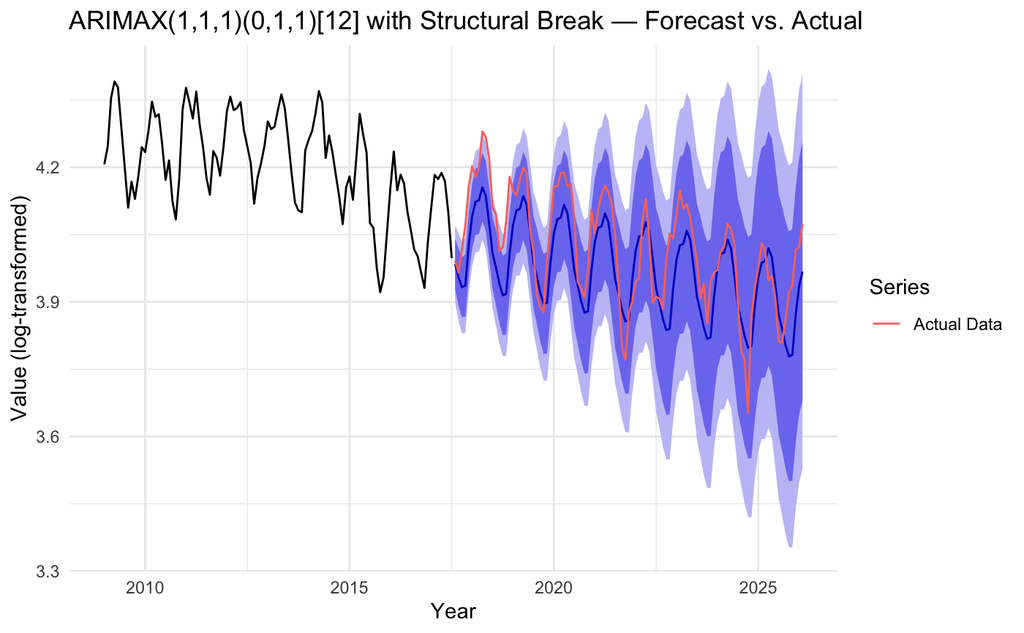

```r
arimax_forecast <- forecast(fit_arimax,
                             h    = length(ts_test_t),
                             xreg = dummy_test)

autoplot(arimax_forecast, include = length(ts_test_t)) +
  autolayer(ts_test_t, series = "Actual Data") +
  labs(title = "ARIMAX(1,1,1)(0,1,1)[12] with Structural Break — Forecast vs. Actual",
       x = "Year", y = "Value (log-transformed)") +
  guides(colour = guide_legend(title = "Series")) +
  theme_minimal()
```

```r
accuracy(arimax_forecast, ts_test_t)
```

```
                       ME       RMSE        MAE         MPE      MAPE      MASE         ACF1 Theil's U
Training set -0.002964599 0.04264953 0.03351961 -0.07910214 0.7931504 0.6441538 -0.004784924        NA
Test set      0.050058616 0.08443884 0.07153569  1.21210084 1.7710758 1.3747174  0.649919694  1.238548
```

A ramp dummy variant was also tested but discarded, as the differencing structure of the model neutralises the ramp’s effect, leaving it with no explanatory power. The fundamental limitation of ARIMA-based models is that they cannot fully accommodate the persistent change in trend introduced by the 2015 structural break, motivating the comparison with alternative approaches in Sections 3.6 and 3.7.

### 3.6 ETS Model

The ETS family models the series through adaptive smoothing equations for level, trend, and seasonality.

```r
ets_fit <- ets(ts_train_t,lambda=NULL) #making sure it doesn't apply another box cox transformation

summary(ets_fit)
```

```
ETS(A,N,A)

Call:
ets(y = ts_train_t, lambda = NULL)

  Smoothing parameters:
    alpha = 0.4712
    gamma = 1e-04

  Initial states:
    l = 4.0987
    s = -0.0037 -0.0544 -0.0948 -0.0806 -0.0628 -0.0364
           0.0159 0.0635 0.0793 0.0757 0.0714 0.0269

  sigma:  0.0456

       AIC       AICc        BIC
-122.65479 -121.00530  -66.75207

Training set error measures:
                        ME       RMSE        MAE         MPE      MAPE      MASE      ACF1
Training set -0.0002308285 0.04450974 0.03500904 -0.01365535 0.8306418 0.6727766 0.1609682
```

The automatic selection with lambda=NULL identifies ETS(A,N,A) — additive error, no trend, additive seasonal. The absence of a trend component means the model projects a flat seasonal pattern, unable to capture the continued decline in the series.

```
    Ljung-Box test

data:  Residuals from ETS(A,N,A)
Q* = 94.603, df = 24, p-value = 2.462e-10

Model df: 0.   Total lags used: 24
```

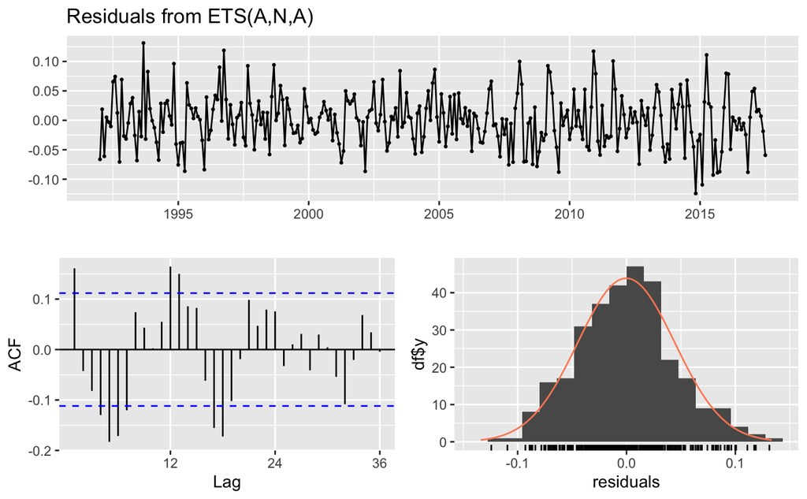

```r
checkresiduals(ets_fit)
```

The Ljung-Box test returns p = 2.46e-10, strongly rejecting H₀. The residuals show substantial autocorrelation, indicating the ETS model fails to capture all the dynamics of the series.

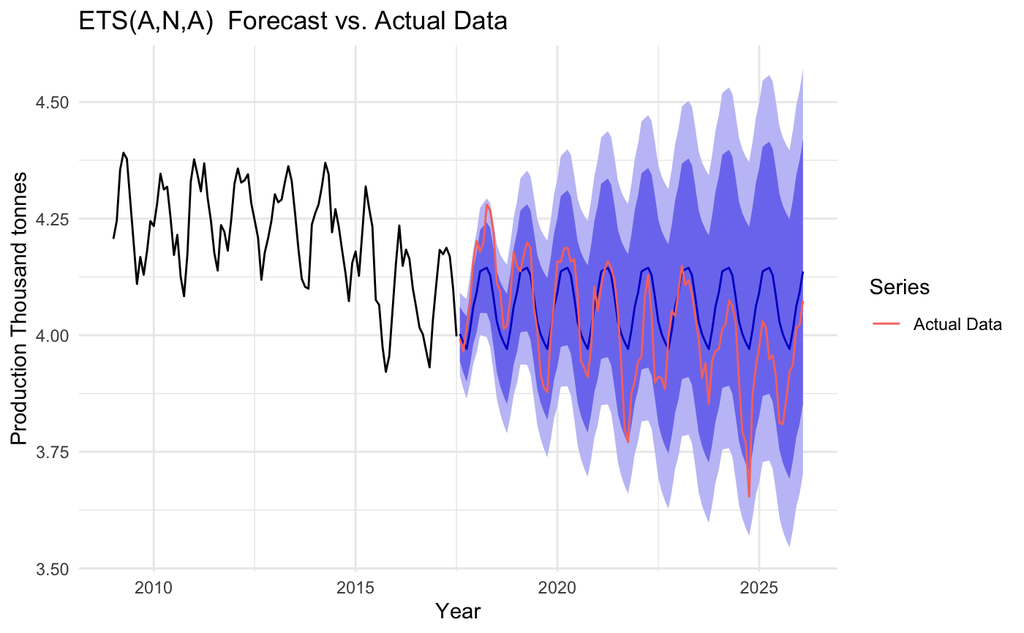

```r
forecast_horizon <- length(ts_test_t)
ets_forecast <- forecast(ets_fit, h = forecast_horizon)

autoplot(ets_forecast, include = forecast_horizon) +
  autolayer(ts_test_t, series = "Actual Data") +
  labs(title = "ETS(A,N,A)  Forecast vs. Actual Data",
       x = "Year", y = "Production Thousand tonnes") +
  guides(colour = guide_legend(title = "Series")) +
  theme_minimal()
```

```r
NA
NA
```

```r
accuracy(ets_forecast, ts_test_t)
```

```
                        ME       RMSE        MAE         MPE      MAPE      MASE      ACF1 Theil's U
Training set -0.0002308285 0.04450974 0.03500904 -0.01365535 0.8306418 0.6727766 0.1609682        NA
Test set     -0.0426931126 0.10157797 0.08198987 -1.12398304 2.0693587 1.5756177 0.8423957  1.524033
```

The ETS forecast maintains the seasonal pattern but projects a flat trajectory, failing to track the continued decline in the test period. The test MAPE of 2.07% and Theil’s U = 1.524 > 1 confirm the model performs worse than a naïve forecast.

### 3.7 STLM-ARIMA Model

```r
stlm_arima_fit <- stlm(ts_train_t, s.window = "periodic", method = "arima")
stlm_arima_fit$model
```

```
Series: x
ARIMA(1,1,1)

Coefficients:
         ar1      ma1
      0.4360  -0.8260
s.e.  0.0735   0.0417

sigma^2 = 0.001849:  log likelihood = 529.39
AIC=-1052.78   AICc=-1052.7   BIC=-1041.61
```

The STLM model decomposes the series using STL (Seasonal and Trend decomposition using Loess), then fits an ARIMA model to the seasonally adjusted component. The internal ARIMA selection identifies ARIMA(1,1,1) for the trend-cycle component.

```
    Ljung-Box test

data:  Residuals
Q* = 41.267, df = 24, p-value = 0.01557

Model df: 0.   Total lags used: 24
```

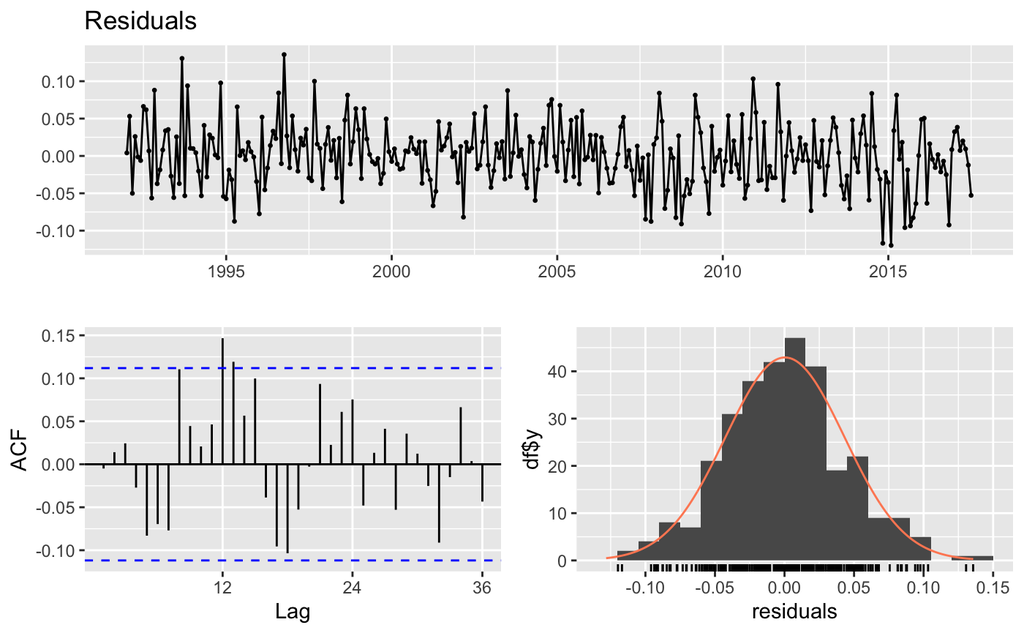

```r
checkresiduals(stlm_arima_fit)
```

The **Ljung-Box test** returns p = 0.016, marginally rejecting H₀ — some residual autocorrelation remains, though substantially less than in the ETS model.

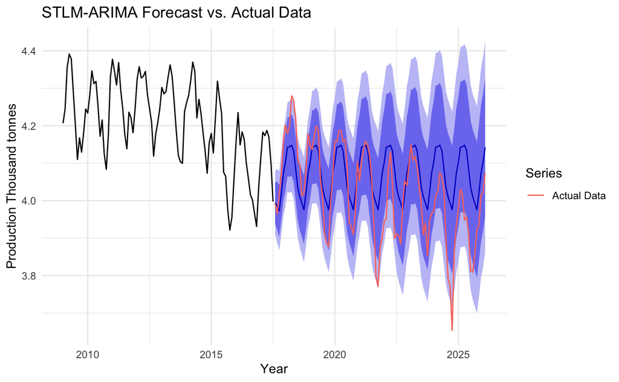

```r
forecast_horizon <- length(ts_test_t)
stlm_forecast <- forecast(stlm_arima_fit, h = forecast_horizon)

autoplot(stlm_forecast, include = forecast_horizon) +
  autolayer(ts_test_t, series = "Actual Data") +
  labs(title = "STLM-ARIMA Forecast vs. Actual Data",
       x = "Year", y = "Production Thousand tonnes") +
  guides(colour = guide_legend(title = "Series")) +
  theme_minimal()
```

```r
accuracy(stlm_forecast,ts_test_t)
```

```
                        ME       RMSE        MAE           MPE      MAPE      MASE         ACF1 Theil's U
Training set  0.0003416735 0.04279466 0.03330732 -0.0004624974 0.7904551 0.6400742 -0.004948073        NA
Test set     -0.0491302858 0.10473693 0.08416036 -1.2847144603 2.1266757 1.6173285  0.843742342  1.573766
```

The STLM forecast achieves a training MAPE of 0.79% and a test MAPE of 2.13%, comparable to the ETS model. Theil’s U = 1.574 > 1 indicates the model performs worse than a naïve forecast out-of-sample.

## 4. Model Comparison

```r
criteria <- data.frame(
  Model = c("SARIMA(1,1,1)(0,1,1)[12]", "SARIMA(1,1,1)(1,1,1)[12]",
            "ARIMAX + break dummy"),
  AIC  = c(AIC(auto_fit_92), AIC(manual_fit), AIC(fit_arimax)),
  AICc = c(AICc(auto_fit_92), AICc(manual_fit), AICc(fit_arimax)),
  BIC  = c(BIC(auto_fit_92), BIC(manual_fit), BIC(fit_arimax))
)
criteria$ΔAIC <- round(criteria$AIC - min(criteria$AIC), 2)
criteria[, -1] <- round(criteria[, -1], 2)
kable(criteria, row.names = FALSE, caption = "Comparison of Information Criteria across Models") %>%
  kable_styling(bootstrap_options = c("striped", "hover", "condensed"), full_width = FALSE)
```

Comparison of Information Criteria across Models

| Model | AIC | AICc | BIC | ΔAIC |
| --- | --- | --- | --- | --- |
| SARIMA(1,1,1)(0,1,1)[12] | -982.22 | -982.08 | -967.48 | 3.05 |
| SARIMA(1,1,1)(1,1,1)[12] | -980.89 | -980.68 | -962.47 | 4.38 |
| ARIMAX + break dummy | -985.27 | -985.06 | -966.85 | 0.00 |

The STLM-ARIMA model is excluded from this comparison as its AIC is computed on the seasonally adjusted series (after STL decomposition), omitting the seasonal component parameters, and is therefore not directly comparable to the SARIMA and ARIMAX models.

```r
results <- rbind(
  `SARIMA(1,1,1)(0,1,1)[12]`  = accuracy(sarima_forecast_92,    ts_test_t)[2, c("RMSE", "MAE", "MAPE", "Theil's U")],
  `SARIMA(1,1,1)(1,1,1)[12]`  = accuracy(sarima_manual_forecast, ts_test_t)[2, c("RMSE", "MAE", "MAPE", "Theil's U")],
  `ARIMAX + break dummy`       = accuracy(arimax_forecast,        ts_test_t)[2, c("RMSE", "MAE", "MAPE", "Theil's U")],
  `ETS(A,N,A)`                 = accuracy(ets_forecast,           ts_test_t)[2, c("RMSE", "MAE", "MAPE", "Theil's U")],
  `STLM-ARIMA`                 = accuracy(stlm_forecast,          ts_test_t)[2, c("RMSE", "MAE", "MAPE", "Theil's U")]
)
kable(round(results, 3), caption = "Forecast Accuracy Comparison on Test Set") %>%
  kable_styling(bootstrap_options = c("striped", "hover", "condensed"), full_width = FALSE)
```

Forecast Accuracy Comparison on Test Set

|  | RMSE | MAE | MAPE | Theil's U |
| --- | --- | --- | --- | --- |
| SARIMA(1,1,1)(0,1,1)[12] | 0.118 | 0.104 | 2.566 | 1.739 |
| SARIMA(1,1,1)(1,1,1)[12] | 0.109 | 0.095 | 2.338 | 1.593 |
| ARIMAX + break dummy | 0.084 | 0.072 | 1.771 | 1.239 |
| ETS(A,N,A) | 0.102 | 0.082 | 2.069 | 1.524 |
| STLM-ARIMA | 0.105 | 0.084 | 2.127 | 1.574 |

ARIMAX with structural break dummy achieves the best out-of-sample performance across all metrics, with a test MAPE of 1.77% and Theil’s U = 1.239. The explicit modelling of the 2015 level shift provides a substantial improvement over the plain SARIMA models. ETS and STLM perform comparably in the middle range (MAPE ≈ 2.1%), while the SARIMA models without structural break modelling perform worst. However, all models yield Theil’s U > 1, indicating that none outperforms a naïve forecast, which is a consequence of the persistent structural change in the series that no model fully accommodates.